This problem focuses on the collinearity problem.

```r
LibraryList<-c("tidyverse", "broom", "ggplot2","modelr")
for (TheLibrary in LibraryList)
{
  if(TheLibrary %in% rownames(installed.packages()) == FALSE) install.packages(TheLibrary)
}
library(tidyverse)
library(broom)
library(ggplot2)
library(modelr)
set.seed(1)  # make sure everybody will have the same "random" numbers
x1 <- runif(100)
x2 <- 0.5 * x1 + rnorm(100) / 10
y <- 2 + 2 * x1 + rnorm(100)
collinearity <- tibble(x1 = x1, x2 = x2, y = y)
```

1. Use the function `cor` to compute the sample correction between `x1` and `x2`.

```r
cor(x1, x2)
```

```
## [1] 0.8351212
```

2. Using this data, fit a least squares regression to predict `y` using `x1` and `x2`. Describe the results obtained. How do estimated coefficients relate to the true coefficients?

```r
(fit0<-lm(y~x1+x2))
```

```
##
## Call:
## lm(formula = y ~ x1 + x2)
##
## Coefficients:
## (Intercept)           x1           x2
##      2.1305       1.4396       0.7097
```

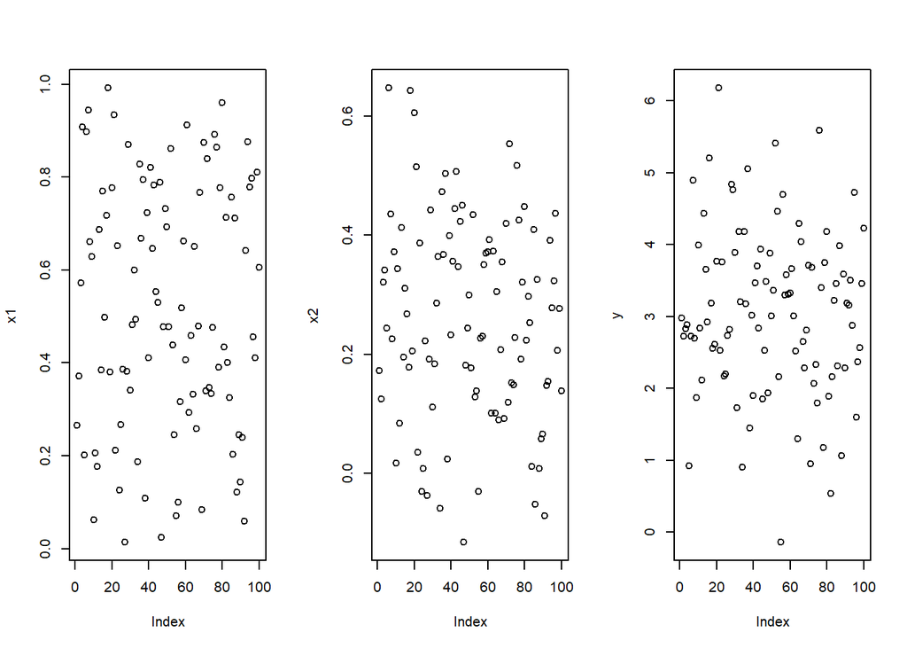

```r
par(mfrow=c(1,3))
plot(x1)
plot(x2)
plot(y)
```

```r
summary(fit0)$coefficients
```

```
##              Estimate Std. Error   t value     Pr(>|t|)
## (Intercept) 2.1304996  0.2318817 9.1878742 7.606713e-15
## x1          1.4395554  0.7211795 1.9961126 4.872517e-02
## x2          0.7096742  1.1337225 0.6259681 5.328060e-01
```

3. Now fit a least squares regression to predict `y` using only `x1`. Comment on your results.

Using just `x1` resulted in a positive increase in slope, which subsequently increased the significance of `x1` because the model was being negatively impacted by `x1`’s correlation with `x2`.

```r
(fit1<-lm(y~x1))
```

```
##
## Call:
## lm(formula = y ~ x1)
##
## Coefficients:
## (Intercept)           x1
##       2.118        1.817
```

```r
summary(fit1)$coefficients
```

```
##             Estimate Std. Error  t value     Pr(>|t|)
## (Intercept) 2.117773  0.2302709 9.196880 6.698531e-15
## x1          1.816559  0.3954634 4.593493 1.297566e-05
```

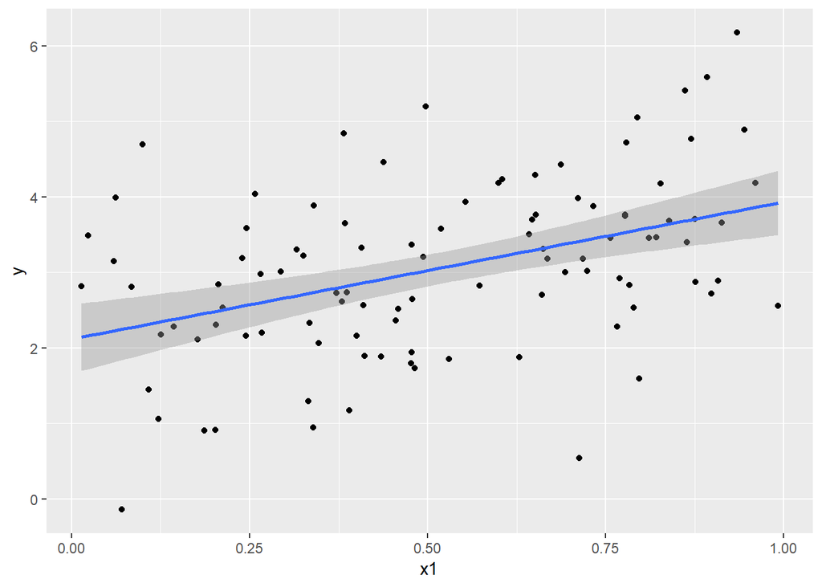

```r
ggplot(collinearity, aes(y = y, x = x1)) + geom_point() +
  geom_smooth(method = "lm", formula = y ~ x)
```

4. Which model, part (b) or part (c), give a smaller prediction error? Use a test set to check it.

With a randomly generated dataset, the model in (b) performs better than (c), but with a subset of the original dataset, (c) has a slightly better performance. Overall, the difference was very small between the two models.

```r
set.seed(2)
new_data <- tibble(y = 2 + 2 * x1 + rnorm(100))
c(mse(fit0, new_data), mse(fit1, new_data))
```

```
## [1] 1.311613 1.328331
```

```r
rp <- resample_partition(collinearity, c(train = 0.7, test = 0.3))
training_set <- as.tibble(rp$train)
testing_set <- as.tibble(rp$test)

c(mse(fit0, testing_set), mse(fit1, testing_set))
```

```
## [1] 0.8257802 0.8026818
```